# Отчёт по лабораторной работе 10

Текстовой редактор vi

Автор

принадлежность

Семёнов Александр Дмитриевич, Student

Российский университет дружбы народов

Дата публикации

2026-04-03

# Информация

## Докладчик

- Семёнов Александр Дмитриевич
- Группа НКАбд-05-25, студент бакалавра
- Российский университет дружбы народов им. П. Лумумбы
- 1032253498@rudn.ru

# Вводная часть

## Цель работы

Познакомиться с операционной системой Linux. Получить практические навыки работы с редактором vi, установленным по умолчанию практически во всех дистрибутивах.

## Задание

- Создать файл, используя редактор vi
- Выполнить редактирование файла: исправить содержимое, удалить фрагменты, добавить новую строку

## Теоретическое введение

### Редактор vi

**vi** (Visual display editor) — интерактивный экранный текстовый редактор, установленный по умолчанию практически во всех дистрибутивах Linux. Он работает в режиме командной строки и не требует графического интерфейса.

### Режимы работы vi

Редактор vi имеет три режима работы:

| Режим | Назначение |
| --- | --- |
| **Командный режим** | Ввод команд редактирования и навигации по файлу. Переход — клавиша `Esc` |
| **Режим вставки** | Ввод и редактирование текста. Переход — клавиши `i`, `a`, `o` и др. |
| **Режим последней строки** | Сохранение изменений, выход из редактора, настройка опций. Переход — `:` (двоеточие) |

### Основные команды

**Навигация:**

- Перемещение курсора: `h` (влево), `l` (вправо), `k` (вверх), `j` (вниз)
- По словам: `w` (вперёд), `b` (назад)
- По строкам: `0` (начало строки), `$` (конец строки)- По файлу: `G` (конец файла), `1G` (начало файла)

**Редактирование:**

- Вставка текста: `i` (перед курсором), `a` (после курсора), `o` (новая строка снизу)
- Удаление: `x` (символ), `dw` (слово), `dd` (строка), `ndd` (n строк)
- Отмена: `u`

### Основные команды

**Сохранение и выход:**

- `:wq` — сохранить и выйти
- `:q!` — выйти без сохранения

### Вызов редактора

vi <имя_файла>

# Выполнение лабораторной работы

1-3. Я ознакомился с теоретическим материалом, с редактором vi и выполнил упражнения, используя команды vi.

## Задание 1. Создание нового файла с использованием vi

1-3. Я перешел в уже созданный каталог lab10, вызвал vi и создал файл hello.sh (рис. 1).

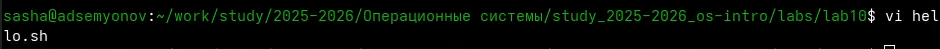

4-5. Нажал клавишу i и ввел текст из методички. Нажал клавишу Esc для перехода в командный режим после завершения ввода текста (рис. 2).

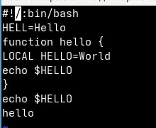

6-7. Нажал : для перехода в режим последней строки. Нажал w и q, а затем нажал Enter для сохранения текста и завершения работы (рис. 3).

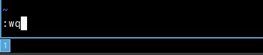

8. Сделал файл исполняемым (рис. 4).

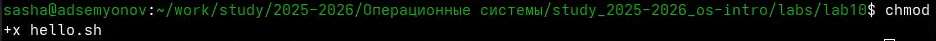

## Задание 2. Редактирование существующего файла

1. Вызвал vi на редактирование файла (рис. 5).

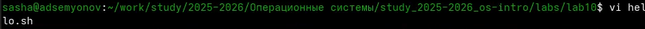

2. Установил курсор в конец слова HELL второй строки, перешел в режим вставки и заменил на HELLO. Нажала Esc для возврата в командный режим (рис. 6).

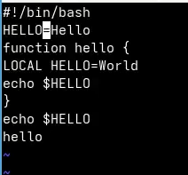

4-5. Установил курсор на четвертую строку и стер слово LOCAL, перешел в режим вставки и набрала следующий текст: local, нажал Esc для возврата в командный режим (рис. 7).

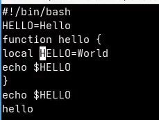

6. Установил курсор на последней строке файла. Вставил после неё строку, содержащую следующий текст: echo $HELLO (рис. 8).

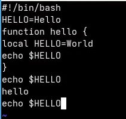

7-8. Нажал Esc для перехода в командный режим и удалил последнюю строку (рис. 9).

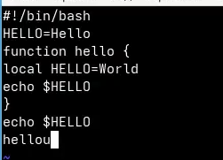

9. Ввел команду отмены изменений u для отмены последней команды (рис. 10).

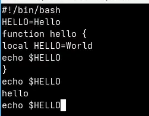

# Выводы

В ходе данной лабораторной работы я познакомился с операционной системой Linux. Получил практические навыки работы с редактором vi, установленным по умолчанию практически во всех дистрибутивах.

# Список лиларатуры

[ТУИС](https://esystem.rudn.ru)